# Premios

El VICCM ofrece varios premios, incluyendo uno a la mejor presentación oral y al mejor poster de un estudiante.

Presentación

Poster

Diego J. Lizcano

January 26, 2026

#### Author

[Diego J. Lizcano](https://mamiferoscolombia.org/VICCM/about/Diego_Lizcano/index.html)

#### Date

26 Enero 2026

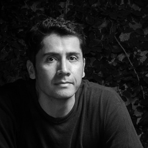

**TipVICCM 2026 - Premios**

## Premio a mejor presentación oral y mejor póster

Una propuesta es elegible para el premio de mejor presentación de un estudiante solo si el/los autor(es) principal(es) es(son) estudiante(s) y en el momento de la presentación, presenta el estudiante. Además, una parte significativa del trabajo debe haber sido realizada por dicho/s estudiante(s). La elegibilidad al premio de estudiante se puede indicar en el momento de someter el resumen.

El Comité Científico podrá seleccionar varias propuestas elegibles para una lista corta. La decisión final se tomará en consulta en el Comité de científico. El premio se anunciará y entregará durante la sesion de clausura del VICCM.

## Premio Jorge Ignacio “El Mono” Hernández

*En reconocimiento a la labor en conservación de mamíferos.*

Jorge Ignacio Hernández-Camacho, mejor conocido como [**“El Mono” Hernández**](https://es.wikipedia.org/wiki/Jorge_Hernández_Camacho) fue un eminente naturalista y mastozoologo que trabajó para crear las primeras áreas protegidas en Colombia, y es considerado padre de los parques nacionales naturales de Colombia.

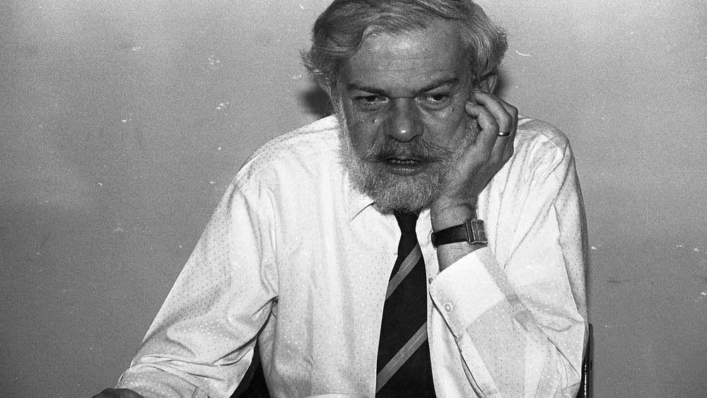

Jorge Ignacio “El Mono” Hernández. Foto de Colprensa

## Premio Alberto Cadena-García

*En reconocimiento a la labor mastozoológica.*

[**Alberto Cadena-García**](https://dialnet.unirioja.es/servlet/articulo?codigo=9388952&orden=0&info=link) fue jefe de la Unidad de Mastozoología del Instituto de Ciencias Naturales (ICN) de la Universidad Nacional desde 1975 hasta su retiro en el año 2000. La colección de Mamíferos del ICN lleva su nombre.

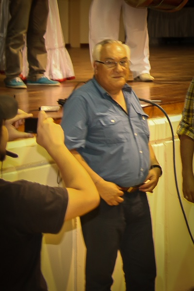

Alberto Cadena-García. Primer congreso de Mastozoología, Quibdó, Choco 2011.

## Premio Adriana Ruíz-Espinosa

*En reconocimiento a un estudiante destacado en mastozoología.*

**Adriana Ruíz-Espinosa** fue una carismatica y reconocida investigadora colombiana dedicada principalmente al estudio de los murciélagos. Adriana estudió Biología en la Universidad de los Andes en Bogotá, y realizó sus posgrados (maestría y doctorado) en la Universidad de los Andes, en Merida, Venezuela. Adriana aportó significativamente a la formación de estudiantes desde su posición como profesora en la Universidad del Valle. Adriana fue Vicepresidenta y fundadora de la Sociedad Colombiana de Mastozoología. [Una especie de murciélago lleva su nombre: *Sturnira adrianae*.](https://doi.org/10.11646/zootaxa.4243.1.3)

[figure not shown]

Adriana Ruíz-Espinosa en su laboratorio de la Universidad del Valle en Cali

El VICCM será posible gracias a la generosa contribucion de los socios de la [SCMas](https://www.mamiferoscolombia.org/La-SCMas/), y es organizado por [La Universidad de la Amazonia](https://www.uniamazonia.edu.co/)

[figure not shown]

[figure not shown]

**Agradecemos a nuestros generosos patrocinadores**

Con sus contribuciones, no solo apoyan esta serie de conferencias, sino también la conservación de la Biodiversidad en Colombia. Si desea convertirse en patrocinador, por favor póngase [en contacto con nosotros acá](https://www.mamiferoscolombia.org/VICCM/contacto/)

This work is licensed under a [Creative Commons Attribution 4.0 License](https://creativecommons.org/licenses/by/4.0/)